# Assignment11

James B

17/11/2020

# Part 1

Explain the following concepts:

1. Statistical hypothesis: Frames the research question we want to answer in terms of the parameters of a statistical model. It enables us to answer the research question by testing it on the basis of observed data modeled as the realised values taken by a collection of random variables.
2. Null hypothesis: The default position we take when attempting to carry out a hypothesis test, typically we declare the absence of any phenomena.
3. Alternative hypothesis: Something of interest that differs from the null, generally a phenomena we wish to prove
4. Test statistic: Is a function of the data which has two characteristics:
1. Has a known distribution under the null hypothesis $H_0$, e.g. a gaussian distribution.
2. Often takes on large or extreme values under the alternative hypothesis $H_1$. The test statistic takes on typical values for $H_0$ -> we accept the null hypothesis $H_0$. The test statistic takes on non-typical values for $H_1$ -> we reject the null & accept the alternative $H_1$.
5. Type 1 error: Where we reject the null hypothesis despite it being actually correct. We are generally more cautious about Type 1 errors than Type 2 errors since the null hypothesis is our default.
6. Type 2 error: Where we fail to reject the null hypothesis when the alternative is actually correct.
7. The size of a test: The test size of a test $\alpha_{test}$ is the probability of Type 1 error under the null hypothesis: $\alpha_{test} = P(Type\ 1\ error\ |\ H_0\ is\ true)$
8. The power of a test: The power of a test is 1 - $\beta_{test}$ where $\beta_{test}$ is the probability of Type 2 error under the alternative: $\beta_{test} = P(Type\ 2\ error\ |\ H_1\ is\ true).$

9, The significance level: The significance of a test $\alpha$ is an upper bound on the test size $\alpha_{test} \leq \alpha$. A valid hypothesis test requires that the significance level be chosen in advance of seeing the data. The lower the significance $\alpha$, the lower the power 1 - $\beta_{test}$. It is the probability of rejecting the null hypothesis give that it is true (a type 1 error), usually set at 5%.

10. The p-value: The probability of obtaining test results at least as extreme as the results actually observed, under the assumption that the null hypothesis $H_0$ is correct. Given test statistic $\hat T$, it is the probability that $\hat T$ is at least as extreme as $\tau$ under the null $H_0$.

# Part 2

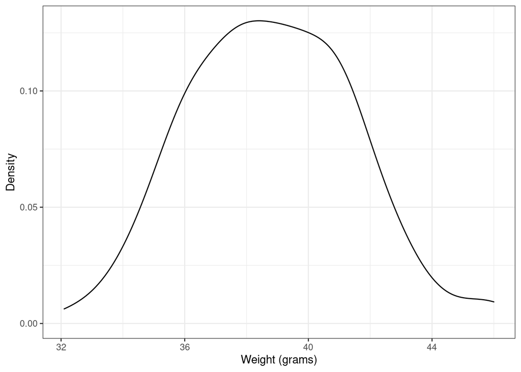

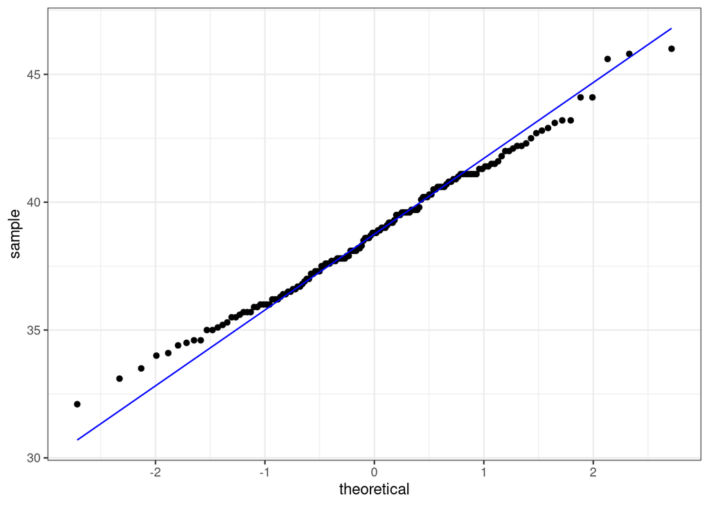

```
##
##  One Sample t-test
##
## data:  bill_adelie
## t = -5.5762, df = 150, p-value = 1.114e-07
## alternative hypothesis: true mean is not equal to 40
## 99 percent confidence interval:
##  38.22590 39.35688
## sample estimates:
## mean of x
##  38.79139
```

For this hypothesis test we must assume that the data is identically and independently distributed, typically in a gaussian pattern, by observing the above graphs we can indeed confirm that these assumptions are well met.

The hypothesis test carried out rejects the null hypothesis that the average bill length is 40mm, when it is actually significantly lower.

# Part 3

```
##
##  Exact binomial test
##
## data:  num_successes and sample_size
## number of successes = 527, number of trials = 619, p-value = 0.07796
## alternative hypothesis: true probability of success is not equal to 0.875
## 95 percent confidence interval:
##  0.8208719 0.8784731
## sample estimates:
## probability of success
##              0.8513732
```

The assumptions for a binomial hypothesis test are the following:

1. Items are dichotomous, i.e. for each item there are two outcomes only, and the data type is nominal / categorical, in this case it refers to whether a plane was on time or not.
2. The sample size is significantly less than the population
3. The sample is a fair representation of the population
4. Sample items are independent and identically distributed

# Part 4

```
## [1] 1.011578e-07
```

```
## [1] 1.114322e-07
```